# Assignment 07

## Homework 7

#### Due Wednesday, November 10, 11:59 PM CT

- This data set must be done sequentially.
- Each problem builds on previous work to build tidy data frame about countries of the world by extracting data from an untidy list object read in from a JSON file.
- Early problems do most of the work for you.
- Later problems ask you to replicate the creation of new variables modeling your answers on the solutions to the earlier problems.

## Obtain the data

For this assignment, we’re going to be working with a JSON dataset of countries of the world. The data is on the course web page, but the original data may be found [**here**](https://raw.githubusercontent.com/mledoze/countries/master/countries.json). Save it to your computer in the course data data directory.

Also read the [data description](https://github.com/mledoze/countries/#countries-data) to see what the variables mean and get an idea of how to access them.

## Read data into R

- This block of code uses `read_json()` from the **tidyjson** package to read the `.JSON` file into a list object in R
- We then use `pluck()` from **purrr** to dive a bit into the tree structure of the data to get the country data
  - At the root level, there are two objects:
    - an integer with the name `document.id` and the value 1
    - a list object with the name “..JSON” that has one element
  - We want to get root element named “..JSON” and then pluck its one element to obtain a list object with one element per country.
  - The first argument of `pluck()` (what we typically pipe in) is the list object.
  - Subsequent arguments traverse down the list structure.

```r
## Read in the countries
countries = read_json("../../data/countries.json") %>%
  pluck("..JSON",1)

## How many countries?
length(countries)
```

```
## [1] 250
```

```r
## How many elements of the first country list?
length(countries[[1]])
```

```
## [1] 23
```

### Problem 1

The previous block of code shows that the `countries` list object has 250 countries and that the first of these has information stored in a list with 23 elements.

Explain the steps of the following block of code to determine how many elements are in the list for each country by answering parts A and B below.

```r
prob1 = tibble(
  n = countries %>%
    map_int(length))

prob1 %>%
  slice(10)
```

```
## # A tibble: 1 × 1
##       n
##   <int>
## 1    23
```

```r
prob1 %>%
  summarize(min = min(n), max = max(n))
```

```
## # A tibble: 1 × 2
##     min   max
##   <int> <int>
## 1    23    23
```

#### A

What are the dimensions of `prob1`?  
-Prob1 is converted into a tibble of 250 rows by 1 column in the first step. It eventually is summarized into a table of 1 row and 2 columns.

What does each row represent?  
-Each row represents the amount of elements that are nested in each countries’ list.

What does the value of `n` in row 10 of the tibble represent? -‘n’ in row 10 of the tibble represents the number of elements present in the tenth country’s list.

#### B

Are there any countries with different numbers of elements in their list? Briefly justify your response.

-No, each country should have the same number of elements (23) based on the fact that both the minimum and maximum values of these lengths were 23.

## Extracting data

- We will practice extracting various fields from the data
- We will build the extracted data into columns of a country data frame

### Problem 2

Recall that **purrr** contained a number of functions to iterate over a list and return data in various formats. Briefly describe the differences between these functions:

- `map()`
- `map_chr()`
- `map_dbl()`
- `map_int()`
- `map_lgl()`

While all map functions can be applied across all elements of a list, the difference between these functions is the type of vector that will be returned (ex. vectors of characters, integers, etc.).

### Problem 3

This block of code displays the names of the elements of the list for the first country (and presumably, for all countries).

```r
countries %>%
  pluck(1) %>%
  names()
```

```
##  [1] "name"         "tld"          "cca2"         "ccn3"         "cca3"
##  [6] "cioc"         "independent"  "status"       "unMember"     "currencies"
## [11] "idd"          "capital"      "altSpellings" "region"       "subregion"
## [16] "languages"    "translations" "latlng"       "landlocked"   "borders"
## [21] "area"         "flag"         "demonyms"
```

The element “name” looks interesting. Let’s examine it for the first two countries.

```r
## First country
countries %>%
  pluck(1, "name")
```

```
## $common
## [1] "Aruba"
##
## $official
## [1] "Aruba"
##
## $native
## $native$nld
## $native$nld$official
## [1] "Aruba"
##
## $native$nld$common
## [1] "Aruba"
##
##
## $native$pap
## $native$pap$official
## [1] "Aruba"
##
## $native$pap$common
## [1] "Aruba"
```

```r
## Second country
countries %>%
  pluck(2, "name")
```

```
## $common
## [1] "Afghanistan"
##
## $official
## [1] "Islamic Republic of Afghanistan"
##
## $native
## $native$prs
## $native$prs$official
## [1] "جمهوری اسلامی افغانستان"
##
## $native$prs$common
## [1] "افغانستان"
##
##
## $native$pus
## $native$pus$official
## [1] "د افغانستان اسلامي جمهوریت"
##
## $native$pus$common
## [1] "افغانستان"
##
##
## $native$tuk
## $native$tuk$official
## [1] "Owganystan Yslam Respublikasy"
##
## $native$tuk$common
## [1] "Owganystan"
```

The element “name” is a list with three elements:

- `$common` is the common name of the country in English
- `$official` is the official name of the country in English
- `$native` is a list with varying number of elements:
  - each element is a list with names that are three-letter codes for a language
  - another level down has `$common` and `$official` entries for the common and official names of the country in those other languages.

Let’s start our country data frame by adding columns with the common and official names of the country in two columns.

- Complete this block of code to create a data frame named `countries_df` with columns `common_name` and `official_name`.
- Note the use of braces `{` and `}` around the right-hand side of the pipe to prevent `countries` from being piped into `tibble()`.
- Subsequent uses of `.` refer to the object on the left-hand side of the pipe, namely `countries`.

```r
countries_df = countries %>%
  {
    tibble(
      common_name = map_chr(., pluck, "name", "common"),
      official_name = map_chr(., pluck, "name", "official"))
  }
```

### Problem 4

Next, let’s get the capital of each country. But some countries may have more than one capital. Examine the `capital` field for the first two countries.

```r
countries %>%
  pluck(1, "capital")
```

```
## [[1]]
## [1] "Oranjestad"
```

```r
countries %>%
  pluck(2, "capital")
```

```
## [[1]]
## [1] "Kabul"
```

It looks like each object `capital` is a list with the name (or names?) of the capital. Add a column to the `countries_df` data frame with a count of how many capitals there are. To get started, here is code which counts the length of the capital list for the first element of `countries`.

```r
countries %>%
  pluck(1, "capital") %>%
  length()
```

```
## [1] 1
```

You now want to use appropriate **purrr** map functions to iterate over the 250 countries and extract the length of the capitol list for each. To do so, we can break this into steps:

- First, iterate over the elements of `countries` to pluck the “capital” items into a list (which **purrr** function returns a list?), each item of which is itself a list
- Second, iterate over the list we just created to extract the length of the list in each element
  - For the first two countries, these lengths will be `1`.
- These lengths will be integers.
  - Which **purrr** function should you use?

Complete the following block by replacing the words FUN with the correct **purrr** function name.

The block repeats the previous code to create a tibble directly from the `countries` list. You should also copy your code from an earlier solution to add the `offical_name` column.

- Change the chunk option `eval = FALSE` to `eval = TRUE` or eliminate it before knitting

```r
countries_df = countries %>%
  {
    tibble(
      common_name = map_chr(., pluck, "name", "common"),
      official_name = map_chr(., pluck, "name", "official"),
      num_captitals = map(., pluck, "capital") %>%
        map_int(length)
    )
  }
head(countries_df)
```

```
## # A tibble: 6 × 3
##   common_name   official_name                   num_captitals
##   <chr>         <chr>                                   <int>
## 1 Aruba         Aruba                                       1
## 2 Afghanistan   Islamic Republic of Afghanistan             1
## 3 Angola        Republic of Angola                          1
## 4 Anguilla      Anguilla                                    1
## 5 Åland Islands Åland Islands                               1
## 6 Albania       Republic of Albania                         1
```

### Problem 5

Which countries have more than one capital? Use `filter()` on `countries_df` as modified by the previous problem to answer.

```r
countries_df %>%
  filter(num_captitals > 1)
```

```
## # A tibble: 1 × 3
##   common_name  official_name            num_captitals
##   <chr>        <chr>                            <int>
## 1 South Africa Republic of South Africa             3
```

### Problem 6

We next wish to add a column `capital` with a string for all capitals separated by a slash “/”.

- For most countries, this will be a single word with the only capital.
- For any country with more than one capital, this will be a single string with all capital names together, separated by a slash.
- To succeed, we want to do the following:
  - Iterate over `countries` and use a **purrr** function to pluck the `capital` field from each country, returned as a list.
    - This will be a list with length the number of countries where each element is a list of one or more capital names
  - Iterate over this list and use the command `str_c()` with argument `collpase = "/"` separately for each element of the list and return a vector of characters

Replace the values of `FUN` in the following block to modify the `tibble()` command from earlier, incorporating earlier answers

```r
countries_df = countries %>%
  {
    tibble(
      common_name = map_chr(., pluck, "name", "common"),
      official_name = map_chr(., pluck, "name", "official"),
      num_captitals = map(., pluck, "capital") %>%
        map_int(length),
      capitals = map(., pluck, "capital") %>%
        map_chr(~{str_c(.x, collapse = "/")})
    )
  }
head(countries_df)
```

```
## # A tibble: 6 × 4
##   common_name   official_name                   num_captitals capitals
##   <chr>         <chr>                                   <int> <chr>
## 1 Aruba         Aruba                                       1 Oranjestad
## 2 Afghanistan   Islamic Republic of Afghanistan             1 Kabul
## 3 Angola        Republic of Angola                          1 Luanda
## 4 Anguilla      Anguilla                                    1 The Valley
## 5 Åland Islands Åland Islands                               1 Mariehamn
## 6 Albania       Republic of Albania                         1 Tirana
```

### Problem 7

Print the data frame for all countries for which there are zero capitals or for which `num_capitals` is recorded as `1` but the capital string is "" (has string length equal to 0).

Modify the data frame so that in each of these cases, the `num_capitals` value is `0L` (the integer 0) and the `capitals` string is “NA_character_” (the missing value with type character so it matches the non-missing value types)

```r
countries_df %>%
  filter((num_captitals == 0) | capitals == "") %>%
  print()
```

```
## # A tibble: 6 × 4
##   common_name                          official_name      num_captitals capitals
##   <chr>                                <chr>                      <int> <chr>
## 1 Antarctica                           Antarctica                     1 ""
## 2 Caribbean Netherlands                Bonaire, Sint Eus…             0 ""
## 3 Bouvet Island                        Bouvet Island                  1 ""
## 4 Heard Island and McDonald Islands    Heard Island and …             1 ""
## 5 Macau                                Macao Special Adm…             1 ""
## 6 United States Minor Outlying Islands United States Min…             1 ""
```

```r
countries_df %>%
  mutate(
    num_captitals = case_when(
      capitals == "" ~ "0L",
      TRUE ~ as.character(num_captitals)),
    capitals = case_when(
      num_captitals == "0" ~ "NA_character_",
      num_captitals == "0L" ~ "NA_character_",
      TRUE ~ capitals)
    )
```

```
## # A tibble: 250 × 4
##    common_name          official_name               num_captitals capitals
##    <chr>                <chr>                       <chr>         <chr>
##  1 Aruba                Aruba                       1             Oranjestad
##  2 Afghanistan          Islamic Republic of Afghan… 1             Kabul
##  3 Angola               Republic of Angola          1             Luanda
##  4 Anguilla             Anguilla                    1             The Valley
##  5 Åland Islands        Åland Islands               1             Mariehamn
##  6 Albania              Republic of Albania         1             Tirana
##  7 Andorra              Principality of Andorra     1             Andorra la Ve…
##  8 United Arab Emirates United Arab Emirates        1             Abu Dhabi
##  9 Argentina            Argentine Republic          1             Buenos Aires
## 10 Armenia              Republic of Armenia         1             Yerevan
## # … with 240 more rows
```

### Problem 8

Following the previous examples, modify the code block to add the following variables:

- `region`: the region of the world where the country is located
- `subregion`: the sub-region of the world where the country is located
- `un_member`: logical if the country is a member of the UN
- `num_languages`: the number of languages in the field “languages”
- `languages`: a vector separated by slashes (`/`) with the languages of each country.

```r
countries_df = countries %>%
  {
    tibble(
      common_name = map_chr(., pluck, "name", "common"),
      official_name = map_chr(., pluck, "name", "official"),
      num_captitals = map(., pluck, "capital") %>%
        map_int(length),
      capitals = map(., pluck, "capital") %>%
        map_chr(~{str_c(.x, collapse = "/")}),
      region = map_chr(., pluck, "region"),
      subregion = map_chr(., pluck, "subregion"),
      un_member = map_lgl(., pluck, "unMember"),
      num_languages = map(., pluck, "languages") %>%
        map_int(length),
      languages = map(., pluck, "languages") %>%
        map_chr(~{str_c(.x, collapse = "/")})
    )
  }
head(countries_df)
```

```
## # A tibble: 6 × 9
##   common_name  official_name   num_captitals capitals region subregion un_member
##   <chr>        <chr>                   <int> <chr>    <chr>  <chr>     <lgl>
## 1 Aruba        Aruba                       1 Oranjes… Ameri… Caribbean FALSE
## 2 Afghanistan  Islamic Republ…             1 Kabul    Asia   Southern… TRUE
## 3 Angola       Republic of An…             1 Luanda   Africa Middle A… TRUE
## 4 Anguilla     Anguilla                    1 The Val… Ameri… Caribbean FALSE
## 5 Åland Islan… Åland Islands               1 Marieha… Europe Northern… FALSE
## 6 Albania      Republic of Al…             1 Tirana   Europe Southeas… TRUE
## # … with 2 more variables: num_languages <int>, languages <chr>
```

### Problem 9

Create and print a full table that filters countries, keeping only those that are members of the United Nations, and then counts the number of countries in each region and sub-region, sorted by region (alphabetically) and by descending counts of the number of countries within each region.

```r
countries_df %>%
  filter(un_member) %>%
  group_by(region, subregion) %>%
  count() %>%
  arrange(region, desc(n))
```

```
## # A tibble: 24 × 3
## # Groups:   region, subregion [24]
##    region   subregion           n
##    <chr>    <chr>           <int>
##  1 Africa   Eastern Africa     17
##  2 Africa   Western Africa     15
##  3 Africa   Middle Africa      10
##  4 Africa   Northern Africa     6
##  5 Africa   Southern Africa     5
##  6 Americas Caribbean          13
##  7 Americas South America      12
##  8 Americas Central America     7
##  9 Americas North America       3
## 10 Asia     Western Asia       16
## # … with 14 more rows
```

### Problem 10

Make a plot with a different facet for each region, each of which contains a barplot that counts the number of countries that have a given number of languages. Use a different fill color for each region.

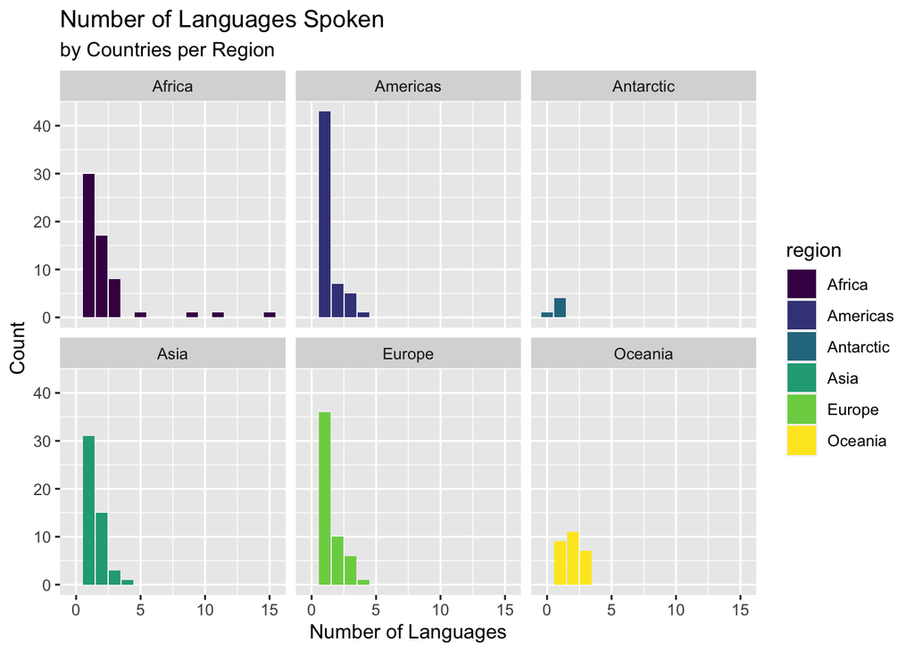

```r
countries_df %>%
  select(region, num_languages) %>%
  ggplot(aes(x=num_languages, fill=region)) +
  geom_bar() +
  facet_wrap(~ region) +
  labs(x = "Number of Languages", y = "Count") +
  ggtitle("Number of Languages Spoken",
          subtitle = "by Countries per Region")
```